# EP3-Modelaje de enfermedades infecciosas.

Carolina Alvarez

2023-01-10

## Examen parcial 3 (Parte 2)

Considera un modelo SIR sin demografía en donde la población se conserva.

1. Escribe y resuelve las ecuaciones diferenciales para valores de R0=beta/gamma = 1.75, 2, 2.5
2. Considera la condición inicial (S=10^6, I=1, R=0)
3. Considera los datos de la pandemia de H1N1 en México. Escoge valores de beta y gamma que den los valores de R0 de arriba pero que ajusten mejor los datos. Sugerencia utiliza un ciclo for para variar los valores.

**R0 = 1.75**

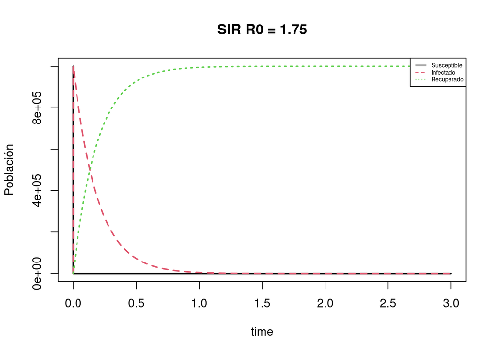

```r
library(deSolve) #Cargar la libreria

SIR <- function(t, state, parameters) { #Crear una nueva función
  with(as.list(c(state, parameters)), { #Definir las ecuaciones
    dS <- -b*S*I
    dI <- b*S*I -d*I
    dR <- d*I
    list(c(dS, dI, dR)) #lista que contiene las ecuaciones del modelo
  })
}
#en el modelo no se incluye la tasa de nacimiento y muerte porque si la poblacion se conserva estas se eliminan en las ecuaciones

parameters <- c(b = 9.2, d = 5.25) #Establecer los parametros
state <- c(S = 10^6, I = 1, R = 0) #establecer las condiciones iniciales
t <- seq(0, 3, by = 0.00001)
out <- ode(state, t, SIR, parameters)

## Grafica del modelo ##
matplot(out[ , 1], out[ , 2:4], type = "l", xlab = "time", ylab = "Población",
        main = "SIR R0 = 1.75", lwd = 2)
legend("topright", c("Susceptible", "Infectado","Recuperado"), col = 1:3,lty=1:3,cex=0.5)
```

```r
#recuadro para señalar cada ecuacion
```

**R0 = 2**

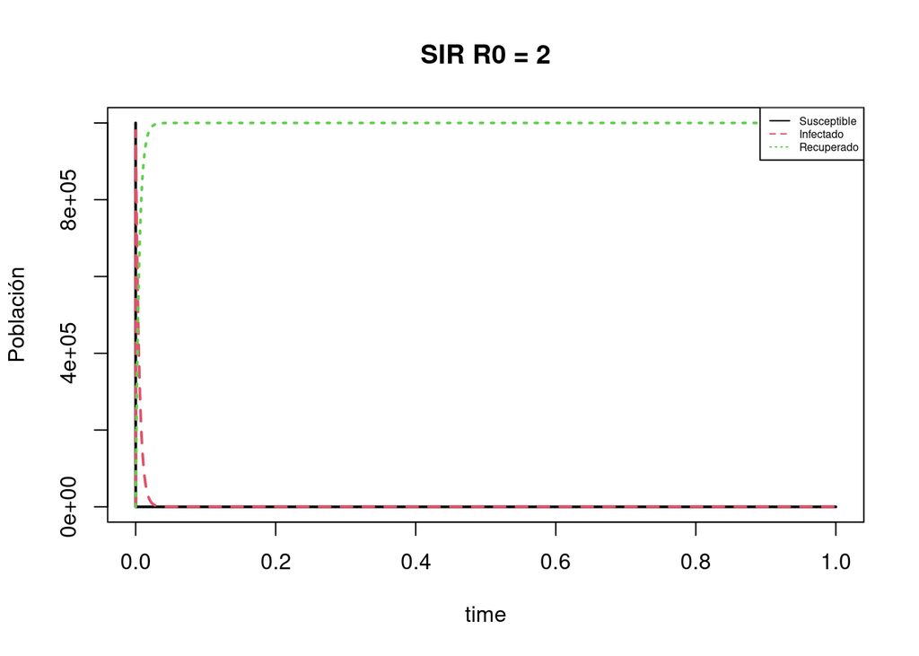

```r
library(deSolve) #Cargar la libreria

SIR2 <- function(t, state, parameters) { #Crear una nueva función
  with(as.list(c(state, parameters)), { #Definir las ecuaciones
    dS <- -b*S*I
    dI <- b*S*I -d*I
    dR <- d*I
    list(c(dS, dI, dR)) #lista que contiene las ecuaciones del modelo
  })
}
#en el modelo no se incluye la tasa de nacimiento y muerte porque si la poblacion se conserva estas se eliminan en las ecuaciones

parameters <- c(b = 400, d = 200) #Establecer los parametros
state <- c(S = 10^6, I = 1, R = 0) #establecer las condiciones iniciales
t <- seq(0, 1, by = 0.0001)
out <- ode(state, t, SIR2, parameters)

## Grafica del modelo ##
matplot(out[ , 1], out[ , 2:4], type = "l", xlab = "time", ylab = "Población",
        main = "SIR R0 = 2", lwd = 2)
legend("topright", c("Susceptible", "Infectado","Recuperado"), col = 1:3,lty=1:3,cex=0.5)
```

```r
#recuadro para señalar cada ecuacion
```

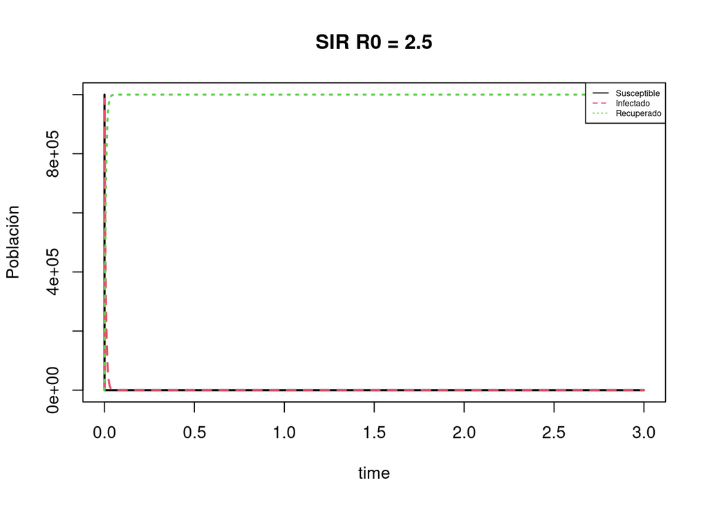

```r
library(deSolve) #Cargar la libreria

SIR3 <- function(t, state, parameters) { #Crear una nueva función
  with(as.list(c(state, parameters)), { #Definir las ecuaciones
    dS <- -b*S*I
    dI <- b*S*I -d*I
    dR <- d*I
    list(c(dS, dI, dR)) #lista que contiene las ecuaciones del modelo
  })
}
#en el modelo no se incluye la tasa de nacimiento y muerte porque si la poblacion se conserva estas se eliminan en las ecuaciones

parameters <- c(b = 370, d = 145) #Establecer los parametros
state <- c(S = 10^6, I = 1, R = 0) #establecer las condiciones iniciales
t <- seq(0, 3, by = 0.0001)
out <- ode(state, t, SIR3, parameters)

## Grafica del modelo ##
matplot(out[ , 1], out[ , 2:4], type = "l", xlab = "time", ylab = "Población",
        main = "SIR R0 = 2.5", lwd = 2)
legend("topright", c("Susceptible", "Infectado","Recuperado"), col = 1:3,lty=1:3,cex=0.5)
```

```r
#recuadro para señalar cada ecuacion
```

Se creo un objeto tipo matriz que contiene los datos, ordenado de acuerdo a los dias de progresion de la pandemia

```r
datos <- read.csv("influenza.csv")
datos
```

```
##     Day Cases
## 1    75     2
## 2    76     1
## 3    77     3
## 4    78     2
## 5    79     3
## 6    80     3
## 7    81     4
## 8    82     4
## 9    83     5
## 10   84     7
## 11   85     3
## 12   86     1
## 13   87     2
## 14   88     5
```

[output cut: 106 more lines]

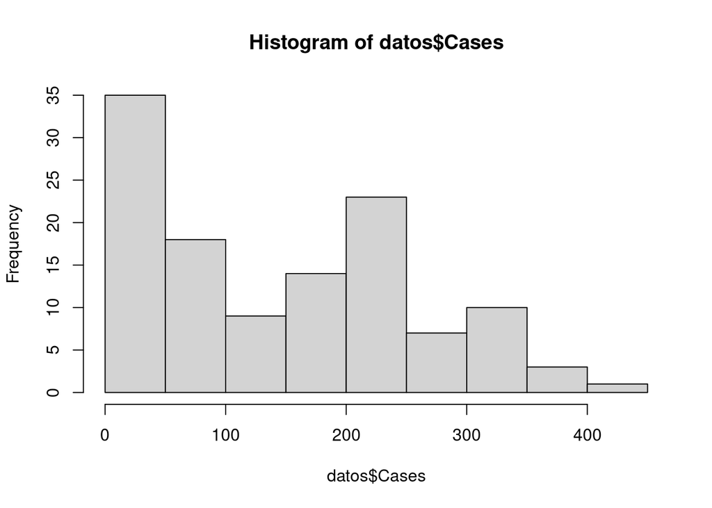

```r
hist(datos$Cases)
```

Para ver la distribucion de los datos se realizo un grafico de puntos que incluye la linea de ajuste usando un modelo de aditivo generalizado (GAM), que da un ajuste de modelos flexible.

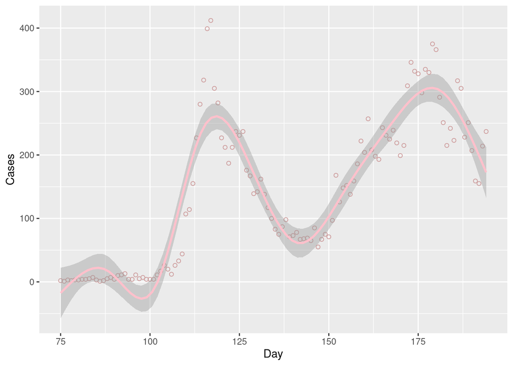

```r
library (ggplot2)

gragam <- ggplot (datos, aes(x=Day, y= Cases))+
  geom_point (shape=1, colour ="rosybrown3") +  #tipo de grafica, una grafica de puntos, shape indica que tipo de punto
  geom_smooth (method= "gam", colour = "pink")      #agrega la linea de ajuste

gragam
```